# Homework 02

## Question 1: Training and test error under a fixed design

Consider a linear regression problem with $n=100$ observations and $p=20$ available covariates. Generate one matrix $\mathbf X_{\mathrm{all}}\in\mathbb R^{n\times p}$ whose entries are independent $\mathcal N(0,1)$ random variables, and then keep this realized matrix fixed. Let

$$\beta_j=0.4^{\sqrt{j}},
\qquad j=1,\ldots,p,$$

and define

$$\boldsymbol\mu=\mathbf X_{\mathrm{all}}\boldsymbol\beta.$$

Generate one training response and one independent test response from

$$\begin{aligned}
\mathbf y
&=\boldsymbol\mu+\boldsymbol\epsilon,\\
\mathbf y^*
&=\boldsymbol\mu+\boldsymbol\epsilon^*,
\end{aligned}$$

where

$$\boldsymbol\epsilon,\boldsymbol\epsilon^*
\overset{\mathrm{ind}}{\sim}
\mathcal N_n(\mathbf 0,\mathbf I_n).$$

Here $\mathbf I_n$ is the $n\times n$ identity matrix.

For $m=0,1,\ldots,p$, fit a linear model with an intercept and the first $m$ columns of $\mathbf X_{\mathrm{all}}$ using $\mathbf y$. If $\widehat{\mathbf y}_m$ is its fitted mean vector, define

$$\operatorname{MSE}_{\mathrm{train},m}
=\frac{1}{n}
\left\lVert
\mathbf y-\widehat{\mathbf y}_m
\right\rVert_2^2,$$

and

$$\operatorname{MSE}_{\mathrm{test},m}
=\frac{1}{n}
\left\lVert
\mathbf y^*-\widehat{\mathbf y}_m
\right\rVert_2^2.$$

Repeat this process independently 200 times, keeping $\mathbf X_{\mathrm{all}}$ fixed.

Use seed `43202` before generating $\mathbf X_{\mathrm{all}}$ and the response errors. R and Python use different random-number generators, so their exact numerical values need not agree.

The design $\mathbf X_{\mathrm{all}}$ is drawn once and then frozen. Everything that varies across the 200 repetitions is response noise, so every expectation below is conditional on that one realized design. Because the design is fixed, each candidate model has a fixed hat matrix $\mathbf H_m$ and the fitted mean is just $\widehat{\mathbf y}_m=\mathbf H_m\mathbf y$, so the 21 hat matrices are computed once and reused. The chunk below produces everything parts a, b, and c refer to.

**Show the starter code**

```
largest single-step increase in training MSE: -1.637526669817646e-09
monotone in all 200 runs: True

  m  bias_mse    train  E_train     test   E_test
  0    0.3178   1.3220   1.3078   1.3416   1.3278
  1    0.1904   1.1815   1.1704   1.2208   1.2104
  2    0.1324   1.1124   1.1024   1.1708   1.1624
  3    0.1127   1.0842   1.0727   1.1577   1.1527
  4    0.0716   1.0319   1.0216   1.1237   1.1216
  5    0.0494   0.9976   0.9894   1.1107   1.1094
  6    0.0327   0.9667   0.9627   1.1050   1.1027
  7    0.0227   0.9457   0.9427   1.1027   1.1027
  8    0.0154   0.9270   0.9254   1.1045   1.1054
  9    0.0125   0.9105   0.9125   1.1153   1.1125
 10    0.0080   0.8960   0.8980   1.1218   1.1180
 11    0.0056   0.8844   0.8856   1.1287   1.1256
 12    0.0044   0.8743   0.8744   1.1355   1.1344
 13    0.0034   0.8634   0.8634   1.1436   1.1434
 14    0.0026   0.8531   0.8526   1.1534   1.1526
 15    0.0019   0.8446   0.8419   1.1605   1.1619
 16    0.0013   0.8322   0.8313   1.1722   1.1713
 17    0.0008   0.8211   0.8208   1.1836   1.1808
 18    0.0004   0.8112   0.8104   1.1938   1.1904
 19    0.0002   0.8009   0.8002   1.2021   1.2002
 20    0.0000   0.7889   0.7900   1.2119   1.2100

argmin average test MSE: 7
argmin expected test MSE: 7
max gap, averages vs theory: 0.0142
sd of test MSE across runs, at the optimum: 0.1542
argmin of run 1's test curve: 14
```

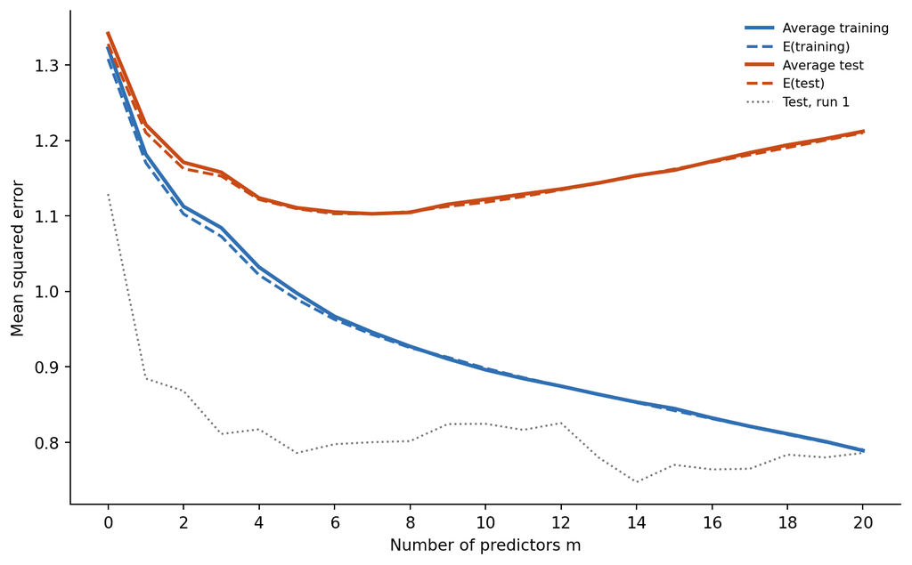

Training and test MSE along the nested model sequence.

```python
import numpy as np
import matplotlib.pyplot as plt

rng = np.random.default_rng(43202)
n, p, n_sim = 100, 20, 200

X_all = rng.normal(size=(n, p))
beta = 0.4 ** np.sqrt(np.arange(1, p + 1))
mu = X_all @ beta

# The design is fixed, so each model's projection matrix is fixed too.
hat_list = []
for m in range(p + 1):
    X_m = np.column_stack((np.ones(n), X_all[:, :m]))
    Q = np.linalg.qr(X_m)[0]
    hat_list.append(Q @ Q.T)

train_mse = np.empty((n_sim, p + 1))
test_mse = np.empty((n_sim, p + 1))

for k in range(n_sim):
    y = mu + rng.normal(size=n)        # training response
    y_star = mu + rng.normal(size=n)   # independent test response

    for m in range(p + 1):
        y_hat = hat_list[m] @ y
        train_mse[k, m] = np.mean((y - y_hat) ** 2)
        test_mse[k, m] = np.mean((y_star - y_hat) ** 2)

# Part b: total squared approximation bias, then the two expectations.
m_values = np.arange(p + 1)
bias_mse = np.array([np.mean((mu - hat_list[m] @ mu) ** 2) for m in m_values])
theory_train = bias_mse + 1 - (m_values + 1) / n
theory_test = bias_mse + 1 + (m_values + 1) / n

average_train = train_mse.mean(axis=0)
average_test = test_mse.mean(axis=0)

# Part a: training MSE must be non-increasing within every single run.
step_changes = np.diff(train_mse, axis=1)
print("largest single-step increase in training MSE:", step_changes.max())
print("monotone in all 200 runs:", bool((step_changes <= 1e-10).all()), "\n")

print(f"{'m':>3}{'bias_mse':>10}{'train':>9}{'E_train':>9}{'test':>9}{'E_test':>9}")
for m in m_values:
    print(f"{m:>3}{bias_mse[m]:>10.4f}{average_train[m]:>9.4f}"
          f"{theory_train[m]:>9.4f}{average_test[m]:>9.4f}{theory_test[m]:>9.4f}")

best = int(np.argmin(average_test))
print("\nargmin average test MSE:", best)
print("argmin expected test MSE:", int(np.argmin(theory_test)))
print("max gap, averages vs theory:",
      round(max(np.abs(average_train - theory_train).max(),
                np.abs(average_test - theory_test).max()), 4))
print("sd of test MSE across runs, at the optimum:",
      round(test_mse[:, best].std(ddof=1), 4))
print("argmin of run 1's test curve:", int(np.argmin(test_mse[0])))

fig, ax = plt.subplots(figsize=(8, 5))
ax.plot(m_values, average_train, color="#2F6FB3", lw=2.3, label="Average training")
ax.plot(m_values, theory_train, "--", color="#2F6FB3", lw=1.8, label="E(training)")
ax.plot(m_values, average_test, color="#C84A16", lw=2.3, label="Average test")
ax.plot(m_values, theory_test, "--", color="#C84A16", lw=1.8, label="E(test)")
ax.plot(m_values, test_mse[0], ":", color="0.45", lw=1.2, label="Test, run 1")
ax.set(xlabel="Number of predictors m", ylabel="Mean squared error",
       xticks=m_values[::2])
ax.spines[["top", "right"]].set_visible(False)
ax.legend(frameon=False, fontsize=8)
fig.tight_layout()
plt.show()
```

1. For each $m$, calculate the average training and test MSE over the 200 simulation runs. Plot both curves against $m$. Verify numerically that training MSE does not increase as predictors are added in each simulation run.

Averaged over the 200 runs, training MSE falls steadily from about $1.32$ at $m=0$ to about $0.79$ at $m=20$. Average test MSE falls from about $1.34$ to a minimum near $m=7$ and then climbs back to about $1.21$ at $m=20$.

The monotonicity check is the stronger statement, and it holds run by run rather than only on average: the largest single-step change in training MSE across all $200\times20$ steps is negative. This is forced by the geometry. The columns of $\mathbf X_m$ are a subset of the columns of $\mathbf X_{m+1}$, so the column space of the smaller model is contained in that of the larger one. Ordinary least squares projects $\mathbf y$ onto that space, and projecting onto a larger subspace cannot leave a larger residual. Training MSE therefore cannot increase when a predictor is added, whatever that predictor happens to be.

2. For the model containing the first $m$ predictors, write

$$\mathbf X_m
=
[\mathbf 1,\mathbf x_1,\ldots,\mathbf x_m],
\qquad
\mathbf H_m
=
\mathbf X_m
(\mathbf X_m^{\mathsf T}\mathbf X_m)^{-1}
\mathbf X_m^{\mathsf T}.$$

Here $\mathbf X_m\in\mathbb R^{n\times(m+1)}$ and $\mathbf H_m\in\mathbb R^{n\times n}$. The model has $m+1$ fitted coefficients, including the intercept. Define its **total squared approximation bias** as

$$B_m^2
=\left\lVert
(\mathbf I_n-\mathbf H_m)\boldsymbol\mu
\right\rVert_2^2.$$

Thus, $B_m^2/n$ is the mean squared approximation bias.

Calculate the two theoretical expectations

$$E\!\left(
\operatorname{MSE}_{\mathrm{train},m}
\mid \mathbf X_{\mathrm{all}}
\right)
=\frac{B_m^2}{n}+1-\frac{m+1}{n},$$

and

$$E\!\left(
\operatorname{MSE}_{\mathrm{test},m}
\mid \mathbf X_{\mathrm{all}}
\right)
=\frac{B_m^2}{n}+1+\frac{m+1}{n}.$$

Add these expectations to your plot and compare them with the simulation averages.

$B_m^2/n$ is the mean squared distance between the true mean vector $\boldsymbol\mu$ and its projection onto the span of $\mathbf X_m$. It drops from $0.3178$ at $m=0$ to essentially $0$ at $m=20$, where the model spans the truth exactly.

The simulation averages sit on top of the theoretical curves. The largest gap between an average and its expectation is about $0.014$, which is roughly one Monte Carlo standard error of a 200-run mean here ($\approx0.012$), so the agreement is as close as 200 repetitions can be expected to give.

The two expectations share the bias term $B_m^2/n$ and differ only in the sign of $(m+1)/n$. Both $B_m^2/n$ and $-(m+1)/n$ decrease in $m$, so expected training MSE decreases throughout and its minimizer is the largest model. In the test expectation the decreasing $B_m^2/n$ is fought by the increasing $(m+1)/n$, and the minimum lands in the interior at $m=7$, exactly where the simulated average test MSE is also minimized.

3. Add the test MSE curve from one simulation run to the plot. Explain why this single curve is less smooth than the average test MSE. Use the approximation-bias and estimation-variance terms in the expected test MSE to explain why training MSE cannot be used by itself to select the predictor count.

The single-run test curve (dotted) wanders. It is one draw of a random variable whose standard deviation is roughly $0.16$ at every $m$, whereas the average over 200 runs has a standard error near $0.012$, about thirteen times smaller. Averaging cancels the noise in $\boldsymbol\epsilon$ and $\boldsymbol\epsilon^*$ and leaves the smooth bias-plus-variance shape; a single curve keeps all of it. In this particular run the minimum falls at $m=14$ rather than $m=7$, which is exactly the kind of error that makes a single held-out curve an unreliable model selector on its own.

Training MSE cannot select $m$ because its expectation moves in the wrong direction with complexity. Expected test MSE pays $+(m+1)/n$ for each extra fitted coefficient, since those coefficients are estimated from $\mathbf y$ but evaluated against an independent $\mathbf y^*$. Expected training MSE receives $-(m+1)/n$ instead: the same estimated coefficients are evaluated against the very response that produced them, so the fit absorbs part of the training noise and the residual shrinks. Training MSE credits flexibility rather than charging for it, so minimizing it always points at the largest model ($m=20$ here) no matter how much of the added flexibility is fitting noise. A penalty such as $C_p$, or an honest held-out estimate, is needed to restore the correct sign.

## Question 2: Prediction error at one target point

Let $n=100$, $p=6$, and $\sigma^2=1$. Construct the fixed covariate matrix $\mathbf X_{\mathrm{all}}\in\mathbb R^{n\times p}$ with entries

$$(\mathbf X_{\mathrm{all}})_{ij}
=\sqrt{2}\cos\left\{
\frac{\pi j(i-\tfrac12)}{n}
\right\},
\qquad
i=1,\ldots,n,
\quad
j=1,\ldots,p.$$

Its columns satisfy

$$\mathbf 1^{\mathsf T}\mathbf X_{\mathrm{all}}=\mathbf 0^{\mathsf T},
\qquad
\frac{1}{n}\mathbf X_{\mathrm{all}}^{\mathsf T}\mathbf X_{\mathrm{all}}=\mathbf I_p.$$

Here $\mathbf I_p$ is the $p\times p$ identity matrix.

The following code shows a direct construction of $\mathbf X_{\mathrm{all}}$.

**Show the starter code**

```python
import numpy as np

n, p = 100, 6
i = np.arange(1, n + 1)[:, None]
j = np.arange(1, p + 1)[None, :]
X_all = np.sqrt(2) * np.cos(np.pi * j * (i - 0.5) / n)
```

Keep $\mathbf X_{\mathrm{all}}$ fixed and generate one training response from

$$\mathbf y
=\mathbf X_{\mathrm{all}}\boldsymbol\beta+\boldsymbol\epsilon,
\qquad
\boldsymbol\beta
=(0.5,0.5,0.5,0.5,0.5,0.5)^{\mathsf T},$$

where

$$\boldsymbol\epsilon
\sim
\mathcal N_n(\mathbf 0,\mathbf I_n).$$

Here $\mathbf I_n$ is the $n\times n$ identity matrix.

For $m=0,\ldots,p$, fit a linear model with an intercept and the first $m$ predictors. Consider prediction of the mean response at

$$\mathbf x_0=(0,1,0,0,1,0)^{\mathsf T}.$$

Write

$$\mu_0=\mathbf x_0^{\mathsf T}\boldsymbol\beta,$$

and let $\widehat\mu_{0,m}$ be the prediction from the model containing the first $m$ predictors. Here $x_{0j}$ denotes the $j$th coordinate of $\mathbf x_0$. For this design,

$$E\!\left[
\left(\widehat\mu_{0,m}-\mu_0\right)^2
\mid \mathbf X_{\mathrm{all}}
\right]
=
\left(
\sum_{j=m+1}^{p}x_{0j}\beta_j
\right)^2
+\frac{\sigma^2}{n}
\left(
1+\sum_{j=1}^{m}x_{0j}^2
\right).$$

1. Calculate $\mu_0$, the theoretical squared bias, and the expected squared error for $m=0,\ldots,p$ using the formula above. **You do not need to derive the formula.** Briefly explain in words why it consists of a squared bias term from omitted predictors and a variance term from estimating coefficients; no proof is required. Identify the values of $m$ where the expected squared error changes and where it remains unchanged.

The target mean is

$$\mu_0=\mathbf x_0^{\mathsf T}\boldsymbol\beta=0.5+0.5=1.$$

Why the formula splits the way it does. The design is orthogonal and centered ($\mathbf 1^{\mathsf T}\mathbf X_{\mathrm{all}}=\mathbf 0^{\mathsf T}$ and $n^{-1}\mathbf X_{\mathrm{all}}^{\mathsf T}\mathbf X_{\mathrm{all}}=\mathbf I_p$), so dropping a predictor does not reshuffle the coefficients that remain. Whatever predictor $j>m$ contributed to the target mean, namely $x_{0j}\beta_j$, is simply left out of the prediction. Summing those omitted contributions and squaring gives the bias term $\left(\sum_{j=m+1}^{p}x_{0j}\beta_j\right)^2$, which is deterministic. The variance term is the sampling variability of the coefficients that are estimated: orthogonality makes $\widehat\beta_1,\ldots,\widehat\beta_m$ and the intercept mutually uncorrelated with variance $\sigma^2/n$ each, and the prediction is the linear combination $\widehat\mu_{0,m}=\widehat\beta_0+\sum_{j\le m}x_{0j}\widehat\beta_j$. Its variance is therefore the sum $\left(\sigma^2/n\right)\left(1+\sum_{j\le m}x_{0j}^2\right)$, with the leading $1$ coming from the intercept.

**Show the starter code**

```python
import numpy as np

n, p, sigma2 = 100, 6, 1.0

i = np.arange(1, n + 1)[:, None]
j = np.arange(1, p + 1)[None, :]
X_all = np.sqrt(2) * np.cos(np.pi * j * (i - 0.5) / n)

beta = np.full(p, 0.5)
x0 = np.array([0.0, 1.0, 0.0, 0.0, 1.0, 0.0])
mu0 = x0 @ beta

# Confirm the two orthogonality properties the formula relies on.
assert np.allclose(X_all.sum(axis=0), 0, atol=1e-10)
assert np.allclose(X_all.T @ X_all / n, np.eye(p), atol=1e-10)

m_values = np.arange(p + 1)
squared_bias = np.array([(x0[m:] @ beta[m:]) ** 2 for m in m_values])
variance = np.array([sigma2 * (1 + x0[:m] @ x0[:m]) / n for m in m_values])
theoretical = squared_bias + variance

print("mu0 =", mu0, "\n")
print(f"{'m':>3}{'squared_bias':>15}{'variance':>11}{'expected':>11}")
for m in m_values:
    print(f"{m:>3}{squared_bias[m]:>15.4f}{variance[m]:>11.4f}"
          f"{theoretical[m]:>11.4f}")
print("\nm values where the expectation changes:",
      (np.flatnonzero(np.diff(theoretical) != 0) + 1).tolist())
```

```
mu0 = 1.0

  m   squared_bias   variance   expected
  0         1.0000     0.0100     1.0100
  1         1.0000     0.0100     1.0100
  2         0.2500     0.0200     0.2700
  3         0.2500     0.0200     0.2700
  4         0.2500     0.0200     0.2700
  5         0.0000     0.0300     0.0300
  6         0.0000     0.0300     0.0300

m values where the expectation changes: [2, 5]
```

| $m$ | Squared bias | Variance | Expected squared error |
| --- | --- | --- | --- |
| 0 | 1.00 | 0.01 | 1.01 |
| 1 | 1.00 | 0.01 | 1.01 |
| 2 | 0.25 | 0.02 | 0.27 |
| 3 | 0.25 | 0.02 | 0.27 |
| 4 | 0.25 | 0.02 | 0.27 |
| 5 | 0.00 | 0.03 | 0.03 |
| 6 | 0.00 | 0.03 | 0.03 |

The expected error changes only at $m=2$ and $m=5$, dropping $1.01\to0.27$ and then $0.27\to0.03$. It is unchanged at $m=1$, $m=3$, $m=4$, and $m=6$. Those are precisely the steps that add a predictor whose target coordinate $x_{0j}$ is zero: such a predictor contributes nothing to the bias sum and adds $x_{0j}^2=0$ to the variance sum, so the expectation is untouched in both terms.

2. Use seed `43203`. Generate the response, fit the models, and calculate

$$\left(\widehat\mu_{0,m}-\mu_0\right)^2.$$

Repeat this independently 200 times. Plot the simulation averages and theoretical expectations together. Report the smallest $m$ that minimizes the theoretical error.

**Show the starter code**

```
  m   simulated   theoretical
  0      0.9839        1.0100
  1      0.9839        1.0100
  2      0.2464        0.2700
  3      0.2464        0.2700
  4      0.2464        0.2700
  5      0.0237        0.0300
  6      0.0237        0.0300

smallest m minimizing the theoretical error: 5
ties at the theoretical minimum: [5, 6]
```

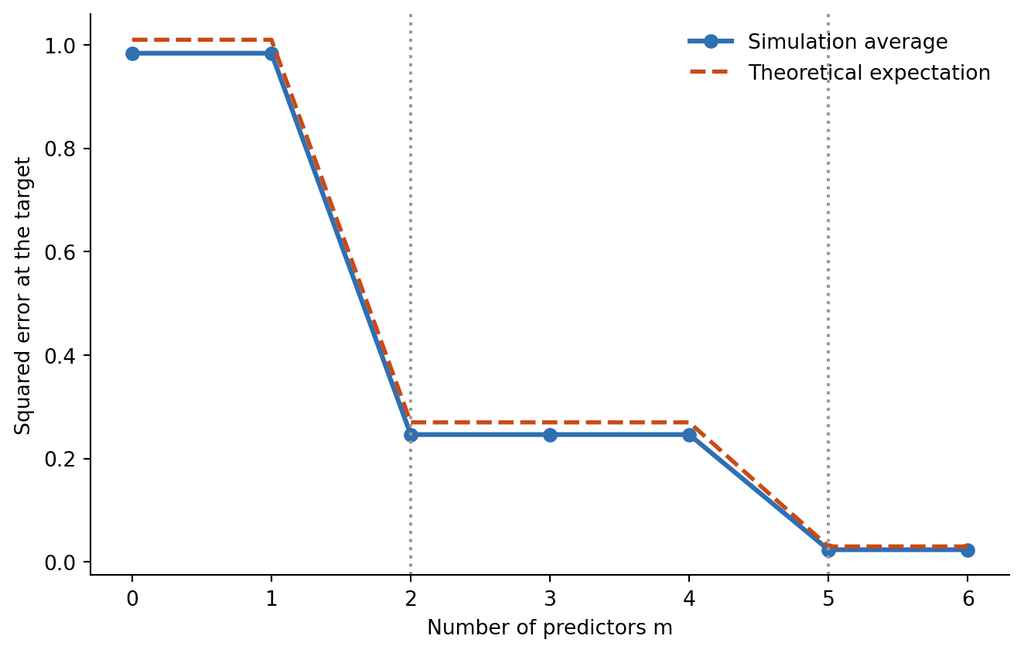

Squared error at the fixed target point.

```python
import matplotlib.pyplot as plt

rng2 = np.random.default_rng(43203)
n_sim = 200
mu = X_all @ beta

sq_error = np.empty((n_sim, p + 1))
for k in range(n_sim):
    y = mu + rng2.normal(size=n)
    for m in m_values:
        X_m = np.column_stack((np.ones(n), X_all[:, :m]))
        beta_hat = np.linalg.solve(X_m.T @ X_m, X_m.T @ y)
        mu0_hat = np.r_[1.0, x0[:m]] @ beta_hat
        sq_error[k, m] = (mu0_hat - mu0) ** 2

simulated = sq_error.mean(axis=0)

print(f"{'m':>3}{'simulated':>12}{'theoretical':>14}")
for m in m_values:
    print(f"{m:>3}{simulated[m]:>12.4f}{theoretical[m]:>14.4f}")
print("\nsmallest m minimizing the theoretical error:",
      int(np.argmin(theoretical)))
print("ties at the theoretical minimum:",
      m_values[np.isclose(theoretical, theoretical.min())].tolist())

fig, ax = plt.subplots(figsize=(7, 4.5))
ax.plot(m_values, simulated, "o-", color="#2F6FB3", lw=2.3,
        label="Simulation average")
ax.plot(m_values, theoretical, "--", color="#C84A16", lw=2,
        label="Theoretical expectation")
ax.axvline(2, color="0.6", ls=":")
ax.axvline(5, color="0.6", ls=":")
ax.set(xlabel="Number of predictors m",
       ylabel="Squared error at the target", xticks=m_values)
ax.spines[["top", "right"]].set_visible(False)
ax.legend(frameon=False)
fig.tight_layout()
plt.show()
```

The simulation reproduces the staircase: flat, a drop at $m=2$, flat, a drop at $m=5$, flat. The smallest $m$ that minimizes the theoretical error is $m=5$, with value $0.03$; $m=6$ ties it, since predictor 6 has $x_{06}=0$ and so adds neither bias reduction nor variance.

The 200-run averages sit slightly below the theory at every $m$ (for example $0.246$ against $0.270$ at $m=2$). That is one draw of Monte Carlo error, not a modelling error: the deviations are common across $m$ because the same 200 response vectors are reused for all seven models. Re-running with 40,000 repetitions returns $1.008,\,1.008,\,0.270,\,0.270,\,0.270,\,0.030,\,0.030$, which matches the theory to three decimals.

3. All six regression coefficients are nonzero. Explain why only predictors 2 and 5 contribute directly to the mean response at $\mathbf x_0$. Contrast this target-specific error with the test MSE averaged over all rows of $\mathbf X_{\mathrm{all}}$ in Question 1.

Every $\beta_j$ equals $0.5$, but the prediction at the target is $\widehat\mu_{0,m}=\widehat\beta_0+\sum_{j\le m}x_{0j}\widehat\beta_j$, and each estimated slope enters multiplied by its target coordinate $x_{0j}$. Since $\mathbf x_0$ has zeros in coordinates 1, 3, 4, and 6, those coefficients are multiplied by zero. They are still nonzero in the truth and still estimated from the data, but they neither shift the prediction at this point nor inflate its variance. Only predictors 2 and 5 carry weight at $\mathbf x_0$.

This is why the answer differs from Question 1. Test MSE there averages $(\widehat\mu_i-\mu_i)^2$ over all $n$ rows of the design, and a predictor earns weight wherever its column is nonzero across those rows. Almost every predictor is nonzero somewhere, so almost every predictor reduces average error, and the optimal $m$ balances bias against variance globally. Prediction at a single point weights predictors by that one point’s coordinates, so a predictor that matters a great deal on average can be irrelevant here, and the optimal $m$ can differ. “Which model is best” is a question about a target, not a property of the model alone.

## Question 3: The optimism correction

Choose one candidate model before observing the response. Let $p$ be its number of predictors and let $\mathbf X\in\mathbb R^{n\times(p+1)}$ be its full-rank design matrix, including the intercept. The model has $p+1$ fitted coefficients. Let

$$\mathbf H
=\mathbf X
(\mathbf X^{\mathsf T}\mathbf X)^{-1}
\mathbf X^{\mathsf T}$$

be its hat matrix. Suppose

$$\mathbf y=\boldsymbol\mu+\boldsymbol\epsilon,
\qquad
\mathbf y^*=\boldsymbol\mu+\boldsymbol\epsilon^*,$$

Conditional on the fixed design $\mathbf X$, the two error vectors are independent, have mean zero, and have covariance matrix $\sigma^2\mathbf I_n$. Define

$$\operatorname{MSE}_{\mathrm{train}}
=
\frac{1}{n}
\left\lVert
\mathbf y-\mathbf H\mathbf y
\right\rVert_2^2,
\qquad
\operatorname{MSE}_{\mathrm{test}}
=
\frac{1}{n}
\left\lVert
\mathbf y^*-\mathbf H\mathbf y
\right\rVert_2^2.$$

The conditional bias vector of the fitted mean is

$$E(\mathbf H\mathbf y\mid\mathbf X)-\boldsymbol\mu
=
-(\mathbf I_n-\mathbf H)\boldsymbol\mu.$$

Let $B^2$ denote the **total squared approximation bias**:

$$B^2
=\left\lVert
(\mathbf I_n-\mathbf H)\boldsymbol\mu
\right\rVert_2^2.$$

Thus, $B^2/n$ is the mean squared approximation bias.

You may use

$$\mathbf H^{\mathsf T}=\mathbf H,
\qquad
\mathbf H^2=\mathbf H,
\qquad
\operatorname{tr}(\mathbf H)=p+1.$$

For any fixed matrix $\mathbf A$, you may also use

$$E\!\left(
\boldsymbol\epsilon^{\mathsf T}
\mathbf A
\boldsymbol\epsilon
\mid \mathbf X
\right)
=\sigma^2\operatorname{tr}(\mathbf A).$$

1. Derive

$$E(\operatorname{MSE}_{\mathrm{train}}\mid\mathbf X)
=\frac{B^2}{n}
+\sigma^2\left(1-\frac{p+1}{n}\right),$$

and

$$E(\operatorname{MSE}_{\mathrm{test}}\mid\mathbf X)
=\frac{B^2}{n}
+\sigma^2\left(1+\frac{p+1}{n}\right).$$

*Training.* Write the training residual using idempotence of $\mathbf I_n-\mathbf H$:

$$\mathbf y-\mathbf H\mathbf y
=(\mathbf I_n-\mathbf H)(\boldsymbol\mu+\boldsymbol\epsilon)
=(\mathbf I_n-\mathbf H)\boldsymbol\mu+(\mathbf I_n-\mathbf H)\boldsymbol\epsilon.$$

Expanding the squared norm gives three pieces:

$$\left\lVert\mathbf y-\mathbf H\mathbf y\right\rVert_2^2
=B^2
+2\boldsymbol\mu^{\mathsf T}(\mathbf I_n-\mathbf H)\boldsymbol\epsilon
+\boldsymbol\epsilon^{\mathsf T}(\mathbf I_n-\mathbf H)\boldsymbol\epsilon,$$

using $(\mathbf I_n-\mathbf H)^{\mathsf T}(\mathbf I_n-\mathbf H)=\mathbf I_n-\mathbf H$. The cross term has expectation zero because $E(\boldsymbol\epsilon\mid\mathbf X)=\mathbf 0$. The quadratic term gives $\sigma^2\operatorname{tr}(\mathbf I_n-\mathbf H)=\sigma^2\left(n-(p+1)\right)$. Hence

$$E\!\left(\operatorname{MSE}_{\mathrm{train}}\mid\mathbf X\right)
=\frac{1}{n}\left[B^2+\sigma^2(n-(p+1))\right]
=\frac{B^2}{n}+\sigma^2\left(1-\frac{p+1}{n}\right).$$

*Test.* The test residual splits into three mutually uncorrelated pieces:

$$\mathbf y^*-\mathbf H\mathbf y
=(\mathbf I_n-\mathbf H)\boldsymbol\mu
+\boldsymbol\epsilon^*
-\mathbf H\boldsymbol\epsilon.$$

All cross terms vanish in expectation: the two involving a single error vector because each has mean zero, and $E(\boldsymbol\epsilon^{*\mathsf T}\mathbf H\boldsymbol\epsilon\mid\mathbf X)=0$ because $\boldsymbol\epsilon$ and $\boldsymbol\epsilon^*$ are independent with mean zero. The surviving terms are

$$E\!\left(\left\lVert\boldsymbol\epsilon^*\right\rVert_2^2\mid\mathbf X\right)=n\sigma^2,
\qquad
E\!\left(\boldsymbol\epsilon^{\mathsf T}\mathbf H\boldsymbol\epsilon\mid\mathbf X\right)
=\sigma^2\operatorname{tr}(\mathbf H)=\sigma^2(p+1),$$

the second using $\mathbf H^{\mathsf T}\mathbf H=\mathbf H$. Therefore

$$E\!\left(\operatorname{MSE}_{\mathrm{test}}\mid\mathbf X\right)
=\frac{1}{n}\left[B^2+\sigma^2 n+\sigma^2(p+1)\right]
=\frac{B^2}{n}+\sigma^2\left(1+\frac{p+1}{n}\right).$$

The asymmetry has a clean reading. The training fit spends $p+1$ dimensions of the noise $\boldsymbol\epsilon$ on itself, removing $\sigma^2(p+1)$ from the residual. Against an independent $\boldsymbol\epsilon^*$ that same fitted noise cannot help, so it is added back instead. The bias term $B^2/n$ is identical in both, because it does not involve noise at all.

2. Deduce the expected optimism, defined as $E(\operatorname{MSE}_{\mathrm{test}}-\operatorname{MSE}_{\mathrm{train}}\mid\mathbf X)$. For

$$n=120,
\qquad
p=4,
\qquad
\frac{B^2}{n}=0.04,
\qquad
\sigma^2=1,$$

calculate the expected training MSE, expected test MSE, and their difference. Explain why the ordering need not hold for every realized pair of responses.

$$E\!\left(\operatorname{MSE}_{\mathrm{test}}-\operatorname{MSE}_{\mathrm{train}}\mid\mathbf X\right)
=\frac{2(p+1)\sigma^2}{n}.$$

The bias term cancels, so the expected optimism depends only on the number of fitted coefficients, the noise level, and the sample size, not on how wrong the model is.

With $n=120$, $p=4$, $B^2/n=0.04$, $\sigma^2=1$, so $(p+1)/n=5/120=1/24$:

$$E(\operatorname{MSE}_{\mathrm{train}}\mid\mathbf X)=0.04+1-\tfrac{1}{24}=0.998333,$$

$$E(\operatorname{MSE}_{\mathrm{test}}\mid\mathbf X)=0.04+1+\tfrac{1}{24}=1.081667,$$

$$\text{expected optimism}=\tfrac{2\cdot5}{120}=\tfrac{1}{12}=0.083333.$$

These are expectations over the joint distribution of $(\boldsymbol\epsilon,\boldsymbol\epsilon^*)$, and both realized MSEs are random. The gap $0.0833$ is small relative to the run-to-run spread of either quantity, so on any given pair of responses an unusually quiet $\boldsymbol\epsilon^*$ or an unusually loud $\boldsymbol\epsilon$ can easily flip the order. The inequality is a statement about long-run averages, not a guarantee for a single dataset.

3. Continue with $n=120$ and $p=4$. Suppose the candidate model has residual sum of squares $\operatorname{RSS}=116.4$, and suppose a common estimate of the error variance is $\widehat\sigma^2=0.96$.

Calculate

$$\widehat{\operatorname{MSE}}_{\mathrm{test}}
=\frac{
\operatorname{RSS}+2(p+1)\widehat\sigma^2
}{n},$$

and

$$C_p
=\frac{\operatorname{RSS}}{\widehat\sigma^2}
-n+2(p+1).$$

Show how these two quantities are related, and explain why minimizing $C_p$ is equivalent to minimizing the corrected test MSE when $n$ and $\widehat\sigma^2$ are common to all candidate models.

$$\widehat{\operatorname{MSE}}_{\mathrm{test}}
=\frac{116.4+2(5)(0.96)}{120}
=\frac{116.4+9.6}{120}
=\frac{126}{120}
=1.05,$$

$$C_p=\frac{116.4}{0.96}-120+2(5)=121.25-120+10=11.25.$$

*Relationship.* Multiply $C_p$ by $\widehat\sigma^2$ and add $n\widehat\sigma^2$:

$$\widehat\sigma^2(C_p+n)
=\operatorname{RSS}-n\widehat\sigma^2+2(p+1)\widehat\sigma^2+n\widehat\sigma^2
=\operatorname{RSS}+2(p+1)\widehat\sigma^2,$$

so

$$\widehat{\operatorname{MSE}}_{\mathrm{test}}
=\frac{\widehat\sigma^2\left(C_p+n\right)}{n}
=\widehat\sigma^2\left(1+\frac{C_p}{n}\right),$$

and the check is $0.96\left(1+11.25/120\right)=0.96\times1.09375=1.05$. Equivalently $C_p=n\widehat{\operatorname{MSE}}_{\mathrm{test}}/\widehat\sigma^2-n$.

*Why the minimizers coincide.* When $n$ and $\widehat\sigma^2$ are held common across all candidate models, the map $C_p\mapsto\widehat\sigma^2\left(1+C_p/n\right)$ is affine with positive slope $\widehat\sigma^2/n>0$. A strictly increasing transformation preserves order, so the two criteria rank every pair of candidates identically and select the same model. The two quantities are the same comparison on different scales: $C_p$ measures penalized fit in units of $\widehat\sigma^2$, and $\widehat{\operatorname{MSE}}_{\mathrm{test}}$ measures it in units of squared response. The equivalence breaks if $\widehat\sigma^2$ is re-estimated separately for each candidate, which is why one common variance estimate from a single reference model is used.

**Show the starter code**

```python
n, p, B2_over_n, sigma2 = 120, 4, 0.04, 1.0

E_train = B2_over_n + sigma2 * (1 - (p + 1) / n)
E_test = B2_over_n + sigma2 * (1 + (p + 1) / n)

print(f"E(train) = {E_train:.6f}")
print(f"E(test)  = {E_test:.6f}")
print(f"optimism = {E_test - E_train:.6f}"
      f"  = 2(p+1)sigma2/n = {2 * sigma2 * (p + 1) / n:.6f}\n")

rss, sigma2_hat = 116.4, 0.96
mse_hat = (rss + 2 * (p + 1) * sigma2_hat) / n
cp = rss / sigma2_hat - n + 2 * (p + 1)

print(f"MSEhat_test = {mse_hat}")
print(f"Cp          = {cp}")
print(f"check sigma2_hat * (Cp + n) / n = {sigma2_hat * (cp + n) / n}")
print(f"check n * MSEhat / sigma2_hat - n = {n * mse_hat / sigma2_hat - n}")
```

```
E(train) = 0.998333
E(test)  = 1.081667
optimism = 0.083333  = 2(p+1)sigma2/n = 0.083333

MSEhat_test = 1.05
Cp          = 11.250000000000014
check sigma2_hat * (Cp + n) / n = 1.05
check n * MSEhat / sigma2_hat - n = 11.25
```

## Question 4: Comparing Mallows’ $C_p$, AIC, and BIC

Use `data/diabetes.csv`, with `y` as the response. Use rows 1 through 370 as the training data, and let $n=370$ denote the training sample size. Do not use rows 371 through 442 in this question. Fit the following ordinary least-squares models, each with an intercept.

| Model | Predictors | $p$ |
| --- | --- | --- |
| Model A | `bmi`, `bp`, `s5`, `sex`, `s1`, `s2`, `s4` | 7 |
| Model B | all predictors in Model A, followed by `s6` | 8 |
| Full reference | all ten predictors | 10 |

Here $p$ counts predictors, so each model has $p+1$ fitted coefficients including the intercept. Estimate one common noise variance from the full reference model, using $p=10$:

$$\widehat\sigma^2
=\frac{\operatorname{RSS}_{\mathrm{full}}}{n-(p+1)}.$$

For Models A and B, calculate

$$C_p
=\frac{\operatorname{RSS}}{\widehat\sigma^2}
-n+2(p+1),$$

$$\operatorname{AIC}^{\mathrm{red}}
=n\log\left(\frac{\operatorname{RSS}}{n}\right)+2(p+1),$$

and

$$\operatorname{BIC}^{\mathrm{red}}
=n\log\left(\frac{\operatorname{RSS}}{n}\right)
+(p+1)\log(n).$$

The reduced AIC and BIC omit constants shared by the two candidate models. Smaller values are preferred within each criterion.

Only rows 1 through 370 are touched here, so $n=370$. The full ten-predictor model is fitted solely to supply one common $\widehat\sigma^2$; if each candidate used its own variance estimate, the $C_p$ comparison would no longer be on a common scale. The chunk below covers all three parts.

**Show the starter code**

```python
import numpy as np
import pandas as pd

training = pd.read_csv("week-02/data/diabetes.csv").iloc[:370]
n = len(training)
y = training["y"].to_numpy()

model_vars = {
    "A": ["bmi", "bp", "s5", "sex", "s1", "s2", "s4"],
    "B": ["bmi", "bp", "s5", "sex", "s1", "s2", "s4", "s6"],
    "Full": ["age", "sex", "bmi", "bp", "s1", "s2", "s3", "s4", "s5", "s6"],
}


def fit_rss(cols):
    # Build the intercept explicitly so p counts predictors, not coefficients.
    X = np.column_stack((np.ones(n), training[cols].to_numpy()))
    residuals = y - X @ np.linalg.lstsq(X, y, rcond=None)[0]
    return float(residuals @ residuals)


rss = {k: fit_rss(v) for k, v in model_vars.items()}
p = {k: len(v) for k, v in model_vars.items()}

residual_df = n - (p["Full"] + 1)
sigma2_hat = rss["Full"] / residual_df

out = pd.DataFrame({"model": ["Model A", "Model B"],
                    "p": [p["A"], p["B"]],
                    "rss": [rss["A"], rss["B"]]})
out["cp"] = out["rss"] / sigma2_hat - n + 2 * (out["p"] + 1)
out["aic"] = n * np.log(out["rss"] / n) + 2 * (out["p"] + 1)
out["bic"] = n * np.log(out["rss"] / n) + np.log(n) * (out["p"] + 1)

print(f"n = {n}  residual df (full) = {residual_df} "
      f" sigma2_hat = {sigma2_hat:.6f}")
print(f"RSS full = {rss['Full']:.3f}\n")
print(out.round(4).to_string(index=False))

cp_gain = (rss["A"] - rss["B"]) / sigma2_hat
fit_gain = n * np.log(rss["A"] / rss["B"])
print(f"\nRSS drop from adding s6: {rss['A'] - rss['B']:.3f}")
print(f"Cp scale gain : {cp_gain:.4f}  vs penalty 2")
print(f"AIC/BIC gain  : {fit_gain:.4f}"
      f"  vs penalty 2 (AIC) and {np.log(n):.4f} (BIC)")
print(f"partial F for s6: {cp_gain:.4f}  -> |t| = {np.sqrt(cp_gain):.4f}")
```

```
n = 370  residual df (full) = 359  sigma2_hat = 3034.684460
RSS full = 1089451.721

  model  p          rss     cp       aic       bic
Model A  7 1098908.5656 8.1163 2974.6403 3005.9483
Model B  8 1089717.0568 7.0874 2973.5325 3008.7540

RSS drop from adding s6: 9191.509
Cp scale gain : 3.0288  vs penalty 2
AIC/BIC gain  : 3.1078  vs penalty 2 (AIC) and 5.9135 (BIC)
partial F for s6: 3.0288  -> |t| = 1.7404
```

1. Fit the three models. Report $p$, RSS, the residual degrees of freedom of the full model, and $\widehat\sigma^2$.

The full model has $n-(10+1)=370-11=359$ residual degrees of freedom, giving

$$\widehat\sigma^2=\frac{1{,}089{,}451.721}{359}=3{,}034.684460.$$

| Model | $p$ | RSS |
| --- | --- | --- |
| Model A | 7 | 1,098,908.566 |
| Model B | 8 | 1,089,717.057 |
| Full reference | 10 | 1,089,451.721 |

Model B’s RSS is already within $265$ of the full model’s, so the two predictors Model B omits (`age` and `s3`) contribute almost nothing to the training fit.

2. Calculate $C_p$, reduced AIC, and reduced BIC for Models A and B. State which model each criterion selects. Do not compare numerical values across different criteria.

| Model | $p$ | $C_p$ | Reduced AIC | Reduced BIC |
| --- | --- | --- | --- | --- |
| Model A | 7 | 8.116 | 2,974.640 | 3,005.948 |
| Model B | 8 | 7.087 | 2,973.532 | 3,008.754 |

$C_p$ selects Model B ($7.087<8.116$). Reduced AIC selects Model B ($2{,}973.532<2{,}974.640$). Reduced BIC selects Model A ($3{,}005.948<3{,}008.754$). The three numeric scales are not comparable to each other, so only the within-column comparisons carry meaning.

3. Compare the improvement in fit from adding `s6` with the one-parameter penalty under each criterion. Use this comparison to explain any disagreement. Why does selecting a model not establish that it is the true data-generating model?

Adding `s6` cuts RSS by $1{,}098{,}908.566-1{,}089{,}717.057=9{,}191.509$. Each criterion converts that reduction to its own scale and charges one extra parameter:

| Criterion | Fit improvement | Penalty for one parameter | Net |
| --- | --- | --- | --- |
| $C_p$ | $(\text{RSS}_A-\text{RSS}_B)/\widehat\sigma^2=3.029$ | $2$ | improvement wins, take B |
| Reduced AIC | $n\log(\text{RSS}_A/\text{RSS}_B)=3.108$ | $2$ | improvement wins, take B |
| Reduced BIC | $n\log(\text{RSS}_A/\text{RSS}_B)=3.108$ | $\log(370)=5.914$ | penalty wins, take A |

The disagreement is entirely explained by the penalty column. $C_p$ and AIC both charge $2$ per parameter, and the improvement of about $3.0$ to $3.1$ clears that bar, so both accept `s6`. BIC charges $\log n=5.914$, nearly three times as much, and the same improvement falls well short, so BIC rejects `s6`. The improvement lands in the narrow window between the two penalties, which is exactly where AIC-type and BIC-type criteria part company. Equivalently, the partial $F$ statistic for `s6` is $3.029$ ($|t|=1.74$), a borderline result that a $2$-unit penalty tolerates and a $5.9$-unit penalty does not.

Selecting a model does not establish that it is the true data-generating model, for several reasons at once. The comparison is only between the two candidates offered; the truth may not be in the list, and it need not even be linear in these ten predictors. Each criterion optimizes a different objective, so “the selected model” is not well defined without saying which criterion. Both criteria are estimates computed from one finite sample, so their ordering is itself random. And the deciding margin here is about $1$ unit on a scale where the criteria disagree with each other, so the evidence distinguishing A from B is weak whichever way it points. The most defensible statement is that `s6` sits near the threshold of usefulness by these criteria, not that either model is correct.

## Question 5: Validation and final test data

Use rows 1 through 370 of `diabetes.csv` as the training data and rows 371 through 442 as the final test data. Consider eleven nested candidate models. For $m=0,1,\ldots,10$, the model with $m$ predictors contains an intercept and the first $m$ predictors in this order:

`age`, `sex`, `bmi`, `bp`, `s1`, `s2`, `s3`, `s4`, `s5`, `s6`.

An analyst proposes the following procedure:

1. Fit all eleven candidate models using the training data.
2. Calculate the MSE of each model on the final test data.
3. Select the model with the smallest test MSE.
4. Report that minimum as the final estimate of prediction error.

The analyst argues that the procedure is valid because the final test data were not used to estimate the regression coefficients.

1. Identify the first step that misuses the final test data. Explain why the minimum of eleven test MSE values is generally too favorable as an estimate of the selected procedure’s future prediction error.

*Step 2 is the first misuse.* As soon as the eleven models are scored on rows 371 through 442, the responses in the final test set enter the analysis. The analyst’s defense, that the test data were not used to estimate coefficients, only covers Step 1. Model selection is part of the fitting procedure, not something separate from it, and Step 3 selects the predictor count using those eleven test-set numbers. By Step 4 the test set has been used twice: once to choose, and again to report. It is no longer held out.

*Why the minimum is too favorable.* Each of the eleven test MSE values equals a true prediction error plus noise from the particular 72 test rows. Taking the minimum over eleven such values does not just find the model with the lowest true error; it also favors whichever model happened to draw the most favorable noise. That selection effect biases the minimum downward, and the bias grows with the number of candidates compared. The reported number is the smallest of eleven noisy estimates rather than an unbiased estimate of the selected model’s error, so it understates what the procedure would achieve on genuinely new data. The problem is the reuse, not the sample size: the same 72 rows cannot both pick the winner and grade it.

2. Rewrite the analysis using five-fold cross-validation within the training data. State how the predictor count is selected, what is refitted, and when the final test data may be used.

A valid rewrite keeps the final test data sealed until the entire procedure, including the choice of $m$, has been fixed:

1. Set aside rows 371 through 442 without looking at their responses.
2. Split rows 1 through 370 into five folds of roughly 74 rows each.
3. For each $m=0,\ldots,10$ and each fold $k=1,\ldots,5$: fit the $m$-predictor model on the four folds excluding $k$, then compute MSE on fold $k$. Any data-dependent preprocessing (centering, scaling, imputation) must be estimated inside the four training folds only, or the same leakage reappears one level down.
4. Average the five validation MSE values to get $\mathrm{CV}_5(m)$.
5. **How $m$ is selected:** choose $m^\star=\arg\min_m \mathrm{CV}_5(m)$. This uses only rows 1 through 370.
6. **What is refitted:** refit the $m^\star$-predictor model on all 370 training rows. The models fitted during cross-validation are used only to score candidates and are then discarded.
7. **When the final test data may be used:** once, at the very end, to evaluate that single refitted model. That one number is the reported estimate of future prediction error, and it is honest because nothing about the test rows influenced $m^\star$ or the coefficients.

If the test estimate is later used to tweak $m$, choose a preprocessing step, or pick among procedures, the test set is spent and the estimate reverts to being optimistic.

The chunk below runs this procedure and, for contrast, also reports what the analyst’s rule would have produced.

**Show the starter code**

```python
import numpy as np
import pandas as pd

diabetes = pd.read_csv("week-02/data/diabetes.csv")
order_vars = ["age", "sex", "bmi", "bp", "s1", "s2", "s3", "s4", "s5", "s6"]
train, test = diabetes.iloc[:370], diabetes.iloc[370:]
y_train, y_test = train["y"].to_numpy(), test["y"].to_numpy()
n_train, n_test = len(train), len(test)


def design(d, m):
    return np.column_stack((np.ones(len(d)), d[order_vars[:m]].to_numpy()))


rng5 = np.random.default_rng(43205)
folds = rng5.permutation(np.resize(np.arange(5), n_train))

cv = np.empty(11)
for m in range(11):
    sse = 0.0
    for k in range(5):
        tr, va = folds != k, folds == k
        b = np.linalg.lstsq(design(train[tr], m), y_train[tr], rcond=None)[0]
        r = y_train[va] - design(train[va], m) @ b
        sse += r @ r
    cv[m] = sse / n_train

m_star = int(np.argmin(cv))
b_final = np.linalg.lstsq(design(train, m_star), y_train, rcond=None)[0]
r = y_test - design(test, m_star) @ b_final
honest = r @ r / n_test

# For contrast only: what the analyst's rule would have reported.
analyst = np.empty(11)
for m in range(11):
    b = np.linalg.lstsq(design(train, m), y_train, rcond=None)[0]
    r = y_test - design(test, m) @ b
    analyst[m] = r @ r / n_test

print(pd.DataFrame({"m": range(11), "cv_mse": cv.round(1),
                    "test_mse": analyst.round(1)}).to_string(index=False))
print(f"\nCV selects m* = {m_star}")
print(f"honest test MSE for the refitted model: {honest:.2f}")
print(f"analyst picks m = {int(np.argmin(analyst))} "
      f"and reports {analyst.min():.2f}")
print(f"understatement: {honest - analyst.min():.2f}")
```

```
 m  cv_mse  test_mse
 0  5971.3    5822.9
 1  5792.4    5527.8
 2  5815.9    5527.2
 3  3943.8    3719.2
 4  3707.1    3246.8
 5  3719.4    3234.9
 6  3731.6    3207.6
 7  3217.0    2636.5
 8  3235.9    2624.9
 9  3139.4    2369.3
10  3121.2    2484.8

CV selects m* = 10
honest test MSE for the refitted model: 2484.78
analyst picks m = 9 and reports 2369.34
understatement: 115.43
```

The contrast is visible in the numbers. The analyst’s rule picks $m=9$ and reports $2{,}369.34$. The cross-validated procedure picks $m^\star=10$ from the training data alone and, evaluated once on the untouched test rows, reports $2{,}484.78$. The analyst’s figure is about $115$ lower, and that gap is pure selection effect, not a better model.

3. Suppose the analyst has already examined all eleven test MSE values. What can still be reported transparently, and what additional data would be needed for a new final evaluation?

*What can still be reported.* The eleven test MSE values are still real numbers and can be shown, provided they are labeled for what they are: an exploratory comparison on data that is no longer held out. The analyst can report the full curve rather than only its minimum, state plainly that the predictor count was chosen using those same values, and note that the reported minimum is therefore a downward-biased estimate of future error. The ranking of the candidates is still informative as a description of this dataset, and the training-data analysis (cross-validation within rows 1 through 370, information criteria, coefficient estimates) is untouched and can be reported normally. Being explicit about the sequence of steps is what keeps the work usable; quietly presenting the minimum as a clean held-out estimate is what would not be.

*What would be needed for a new final evaluation.* A genuinely independent sample whose responses have not influenced any modelling decision. That means either a fresh set of patients from the same population, or future observations collected after the procedure was fixed. Re-splitting rows 1 through 442 does not help, since every row has now been seen. Nor does switching criteria on the same data. If new data cannot be collected, the honest fallback is to report a cross-validated estimate computed on the training rows, where $m$ is selected inside each fold so that the selection step is itself validated, and to describe the test-set numbers as exploratory.

## Reference

James, Witten, Hastie, Tibshirani, and Taylor, [*An Introduction to Statistical Learning*](https://www.statlearning.com/), Chapters 3, 5, and 6.